# Part II - (The Influence of EmploymentStatus and Term on Loan Status)

## by (Akpan Enwongo Boniface

## Investigation Overview

> In this investigation, I want to assess the variables that may affect the loan status and may be used to identify trends in delinquency. The focus is on the Term, EmploymentStatus and Loan Status.

## Dataset Overview

> The dataset contains 113066 entries with 81 variables including Term, Employment Status and the Loan Status. The data points were reduced to 110809 due to inconsistencies. Loan Status will be re-grouped into Charged off, Delinquent Payments and Non Delinquent Payments and the categories in the Employment Status were reduced to Employed,Full-time, Not employed, Self-employed, Part-time and Retired.

## (Loan Status Distribution)

The clustered bar chart below shows the distribution of both status. The Charged Off payments are over 11,000 data points and the past due payments over 6,000 data points.

We have borrowers with more bad debt -debts that may not be recovered(Charged Off) compared to those with delinquent (past due) payments.

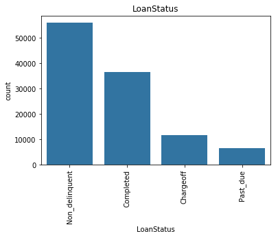

## (LoanStatus Vs EmploymentStatus)

There were more non delinquent payments for the self employed and Employed borrowers,, while there were more completed payments for the full time, Part time and Retired borrowers.

The Part time and Retired borrowers did not have past due payments.Full time had the most completed payment, Employed had the most Non delinquent payment and the most past due payment, while full time had the most charge off loans.

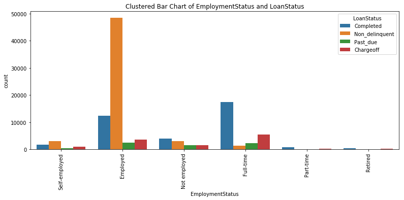

## (LoanStatus Vs Term)

The 36-month term had the highest distribution for all classes under LoanStatus, followed by the 60-month term. Only completed payments were seen under the 12-month term.

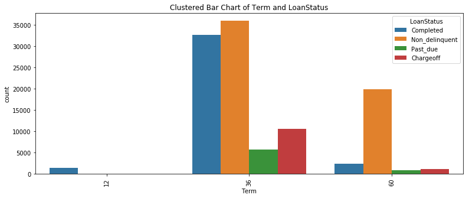

## (Term Vs EmploymentStatus)

Borrowers with the employed status had the most distribution across the three terms. There were no retirees and part time workers at the 60-month term. The 12-month term has the least distribution of workers.

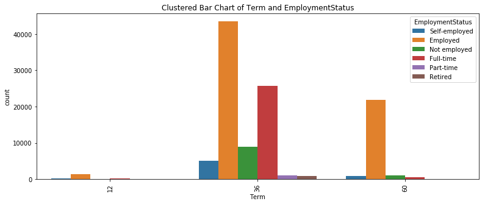

## (LoanStatus Vs Term Vs EmploymentStatus)

At the 60-month term, we had more employed borrowers with charged off loans.

[figure not shown]